# Calculating restriction enzyme fragment numbers for Pythium irregulare

Javier F. Tabima

September 16, 2015

# The rationale

There is an interest in genotyping samples of the genus *Pythium*. In order to avoid the same complications that we had with other species, lets perform a virtual restriction enzyme assay using the classic enzyme for GBS **ApeKI**, a the recommended pair of enzymes: **PstI** and **Msp1** and a new 8-base cutter **SbfI**. We want to compare the number of fragments and per-base coverage of the two enzyme method with the ApeKI method using the reference genome of *P. irregulare*.

## The enzymes:

### ApeKI

Restriction endonuclease `ApeKI` recognizes the sequence “GCWGC” in double stranded DNA and cuts after the first position on each strand:

### PstI

`PstI`, is a Type II restriction enzyme from *Providencia stuartii*:

### MspI

`MspI`, is a Type II restriction enzyme. It was used for methylation analyzes as it was able to cut [hydroxymethylated DNA](http://www.ncbi.nlm.nih.gov/pmc/articles/PMC342244/).

### Interaction between the two restriction enzymes.

The MspI adapter is designed as a Y-adapter. During amplification the reverse primer is identical to the Y tail of the common adapter and can only anneal if the complimentary strand has first been synthesized from the other end. This prevents the amplification of the MspI-MspI fragments and adapter dimers as fragments that have Y adapters (P2 adapters) on both ends will not be amplified via PCR.

### Sbf1

SbfI is a restriction enzyme that recognizes CCTGCA^GG and its not dam methylation-sensitive, not dcm methylation-sensitive and not CpG methylation-sensitive.

## Dataset

- Inputs:
1. Reference genome of *Pytium irregulare*:`http://fungidb.org/common/downloads/release-3.2/Pirregulare_DAOMBR486/fasta/data/FungiDB-3.2_Pirregulare_DAOMBR486_Genome.fasta`
2. Enzymes for SimRAD:
- `ApeKI`
- `Pst1` and `Msp1`
- `SbfI`

## Loading the library and the *Pythium irregulate* genome

```r
library(SimRAD)
#Reference Sequence: PLEASE CHANGE TO THE FOLDER WHERE YOU DOWNLOADED THE GENOME
setwd("/Users/tabimaj/Documents/Pythium")
pyirr.c <- ref.DNAseq("FungiDB-3.2_Pirregulare_DAOMBR486_Genome.fasta",subselect.contigs = F)
```

## ApeKI

```r
# ApeKI : G|CWGC  which is equivalent of either G|CAGC or  G|CTGC
cs_5p1 <- "G"
cs_3p1 <- "CAGC"
cs_5p2 <- "G"
cs_3p2 <- "CTGC"
pyirr.dig.ape <- insilico.digest(pyirr.c , cs_5p1, cs_3p1, cs_5p1, cs_3p1, verbose=TRUE)
```

```
## Number of restriction sites for the first enzyme: 120807
## Number of restriction sites for the second enzyme: 120807
## Number of type AB and BA fragments:241614
## Number of type AA fragments:120807
## Number of type BB fragments:120807
```

```
## 75328 fragments between 100 and 1000 bp
```

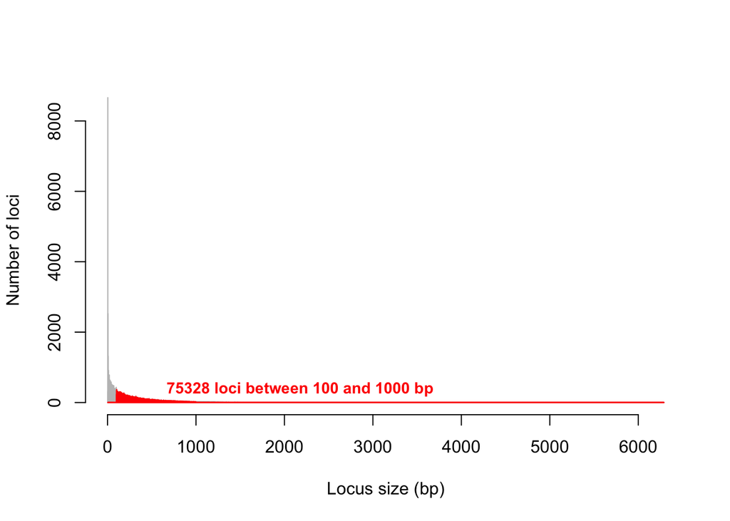

```r
## Size selection (100bp ~ Max length)
pyirr.size.selected.ape <- size.select(pyirr.dig.ape,min.size = 100,max.size = 1000,graph = T)
```

### Total nucleotides

If we have a genome with a total size of 42,968,084 base pairs, we divide the number of total nucleotides sequenced by using this method (11,850,999), we will have 27.5809343% of the genome represented.

## PstI / MspI

```r
#Restriction Enzyme 1
 #PstI
    cs_5p1 <- "CTGCA"
    cs_3p1 <- "G"
#Restriction Enzyme 2
 #MspI
    cs_5p2 <- "C"
    cs_3p2 <- "CGG"
# double digestion:
pyirr.dig <- insilico.digest(pyirr.c, cs_5p1, cs_3p1, cs_5p2, cs_3p2, verbose=TRUE)
```

```
## Number of restriction sites for the first enzyme: 26516
## Number of restriction sites for the second enzyme: 80441
## Number of type AB and BA fragments:37984
## Number of type AA fragments:7524
## Number of type BB fragments:61448
```

```r
#selection of AB type fragments
pyirr.selected <- adapt.select(pyirr.dig, type="AB+BA", cs_5p1, cs_3p1, cs_5p2, cs_3p2)
```

We have 37984 regions with `Pse1-Msp1` flanking regions. After size selection for anything greater than 100bp:

```
## 25255 fragments between 100 and 1000 bp
```

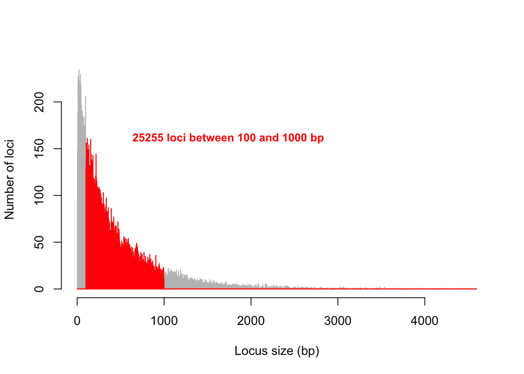

```r
## Size selection (100bp ~ Max length)
pyirr.size.selected <- size.select(pyirr.selected,min.size = 100,max.size = 1000,graph = T)
```

### Total nucleotides

If each of the reads have 100bp maximum (Using a single end Illumina 3000 lane), in theory we will have 100 * Number of regions = Total nucleotides. We have regions greater than 100bp, and this can lead to more than one 100 bp reads per cluster. In this case, regions greater than 200bp will have a maximum of two different 100bp reads: 200bp per region. For regions greater than 100 and lesser than 200bp, the length will be 100bp + the rest of the region:

If we have a genome with a total size of 42,968,084 base pairs, we divide the number of total nucleotides sequenced by using this method (4,076,295), we will have 9.4867972% of the genome represented.

# Comparison

| Enzyme | Number of fragments | Number of nucleotides | Percentage of genome sequenced |
| --- | --- | --- | --- |
| `ApeKI` | 75,328 | 11,850,999 | 27.5809343 |
| `Pst1 + Msp1` | 25,255 | 4,076,295 | 9.4867972 |

# Average coverage per sample.

Lets assume we have 96 samples, and in a perfect world the Illumina 3000 in a lane should sequence 300e+6 reads, or 30 Gigabases (30,000,000,000 bases).

If we have 96 samples in a lane, then the Illumina sequencer should provide us with 312,500,000 nucleotides per sample. If we divide the number of nucleotides obtained per sample *P. irregulare* genome by the number of nucleotides per sample per lane we can obtain the average base coverage:

| Enzyme | Number of nucleotides | Percentage of genome sequenced | Average base coverage for 96 samples |
| --- | --- | --- | --- |
| No Enzyme | 42,968,084 | 100 | 7.27284 |
| `ApeKI` | 11,850,999 | 27.58 | 26.36909 |
| `Pst1 + Msp1` | 4,076,295 | 9.49 | 76.66275 |

> NOTE: Remember that the read distribution is not uniform, and this is just an approach based on uniformity and upper limits on the Illumina HiSeq 3000 sequencing machine.

## SbfI

```r
# SbfI  : 8 Base cutter: CCTGCA^GG

cs_5p1 <- "CCTGCA"
cs_3p1 <- "GG"
cs_5p2 <- "GG"
cs_3p2 <- "CCTGCA"
pyirr.dig.sbf <- insilico.digest(pyirr.c , cs_5p1, cs_3p1, cs_5p1, cs_3p1, verbose=TRUE)
```

```
## Number of restriction sites for the first enzyme: 968
## Number of restriction sites for the second enzyme: 968
## Number of type AB and BA fragments:1934
## Number of type AA fragments:967
## Number of type BB fragments:967
```

```
## 16 fragments between 100 and 1000 bp
```

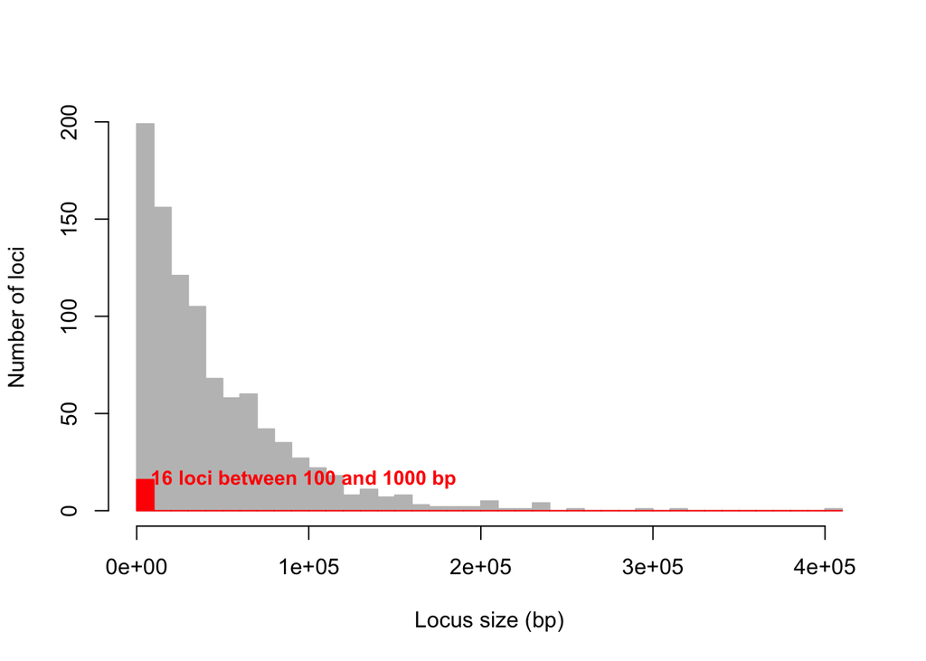

```r
## Size selection (100bp ~ Max length)
pyirr.size.selected.sbf <- size.select(pyirr.dig.sbf,min.size = 100,max.size = 1000 ,graph = T)
```

### Total nucleotides

```r
bp_1.sbf <- sum(unlist(lapply(pyirr.size.selected.sbf, function (x) nchar(x))) == 100) * 100
bp_2.sbf <- sum(unlist(lapply(pyirr.size.selected.sbf, function (x) nchar(x))) >= 200) * 200
bp_1.5.sbf <- sum(unlist(lapply(pyirr.size.selected.sbf, function (x) nchar(x))) > 100 & unlist(lapply(pyirr.size.selected.sbf, function (x) nchar(x))) < 200) + sum(abs(100 - unlist(lapply(pyirr.size.selected.sbf, function (x) nchar(x)))[unlist(lapply(pyirr.size.selected.sbf, function (x) nchar(x))) > 100 & unlist(lapply(pyirr.size.selected.sbf, function (x) nchar(x))) < 200]))
total_nucs.sbf <- bp_1.sbf + bp_2.sbf + bp_1.5.sbf
```

If we have a genome with a total size of 42,968,084 base pairs, we divide the number of total nucleotides sequenced by using this method (2,601), we will have 0.0060533% of the genome represented.

# Comparison

| Enzyme | Number of fragments | Number of nucleotides | Percentage of genome sequenced |
| --- | --- | --- | --- |
| `ApeKI` | 75,328 | 11,850,999 | 27.5809343 |
| `Pst1 + Msp1` | 25,255 | 4,076,295 | 9.4867972 |
| `SbfI` | 16 | 2,601 | 0.0060533 |

# Average coverage per sample.

Lets assume we have 96 samples, and in a perfect world the Illumina 3000 in a lane should sequence 300e+6 reads, or 30 Gigabases (30,000,000,000 bases).

If we have 96 samples in a lane, then the Illumina sequencer should provide us with 312,500,000 nucleotides per sample. If we divide the number of nucleotides obtained per sample *P. irregulare* genome by the number of nucleotides per sample per lane we can obtain the average base coverage:

[output not shown]

## SbfI + MspI

```r
#Restriction Enzyme 1
 #SbfI
    cs_5p1 <- "CCTGCA"
    cs_3p1 <- "GG"
#Restriction Enzyme 2
 #MspI
    cs_5p2 <- "C"
    cs_3p2 <- "CGG"
# double digestion:
pyirr.dig <- insilico.digest(pyirr.c, cs_5p1, cs_3p1, cs_5p2, cs_3p2, verbose=TRUE)
```

```
## Number of restriction sites for the first enzyme: 968
## Number of restriction sites for the second enzyme: 80441
## Number of type AB and BA fragments:1912
## Number of type AA fragments:12
## Number of type BB fragments:79484
```

```r
#selection of AB type fragments
pyirr.selected <- adapt.select(pyirr.dig, type="AB+BA", cs_5p1, cs_3p1, cs_5p2, cs_3p2)
```

```
## 1179 fragments between 100 and 1000 bp
```

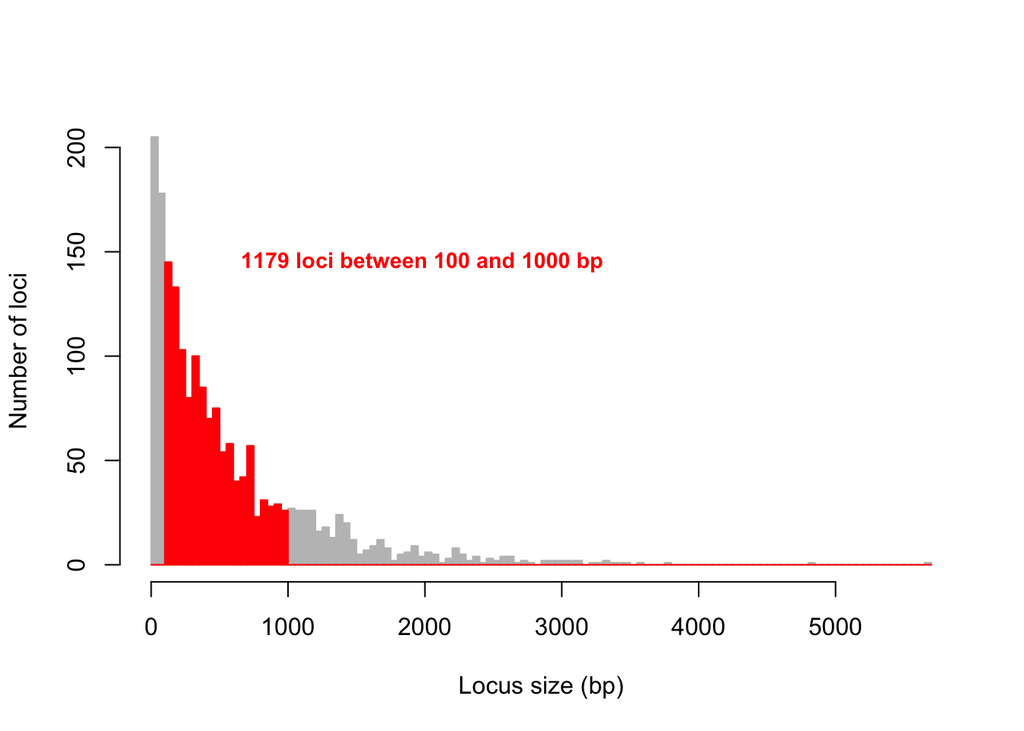

```r
## Size selection (100bp ~ Max length)
pyirr.size.selected.sbf.msp <- size.select(pyirr.selected,min.size = 100,max.size = 1000,graph = T)
```

### Total nucleotides

```r
bp_1.sbf.msp <- sum(unlist(lapply(pyirr.size.selected.sbf.msp, function (x) nchar(x))) == 100) * 100
bp_2.sbf.msp <- sum(unlist(lapply(pyirr.size.selected.sbf.msp, function (x) nchar(x))) >= 200) * 200
bp_1.5.sbf.msp <- sum(unlist(lapply(pyirr.size.selected.sbf.msp, function (x) nchar(x))) > 100 & unlist(lapply(pyirr.size.selected.sbf.msp, function (x) nchar(x))) < 200) + sum(abs(100 - unlist(lapply(pyirr.size.selected.sbf.msp, function (x) nchar(x)))[unlist(lapply(pyirr.size.selected.sbf.msp, function (x) nchar(x))) > 100 & unlist(lapply(pyirr.size.selected.sbf.msp, function (x) nchar(x))) < 200]))
total_nucs.sbf.msp <- bp_1.sbf.msp + bp_2.sbf.msp + bp_1.5.sbf.msp
```

If we have a genome with a total size of 42,968,084 base pairs, we divide the number of total nucleotides sequenced by using this method (194,207), we will have 0.4519797% of the genome represented.

# Comparison

| Enzyme | Number of fragments | Number of nucleotides | Percentage of genome sequenced |
| --- | --- | --- | --- |
| `ApeKI` | 75,328 | 11,850,999 | 27.5809343 |
| `Pst1 + Msp1` | 25,255 | 4,076,295 | 9.4867972 |
| `SbfI` | 16 | 2,601 | 0.0060533 |
| `SbfI + MspI` | 1,179 | 194,207 | 0.4519797 |

# Average coverage per sample.

Lets assume we have 96 samples, and in a perfect world the Illumina 3000 in a lane should sequence 300e+6 reads, or 30 Gigabases (30,000,000,000 bases).

If we have 96 samples in a lane, then the Illumina sequencer should provide us with 312,500,000 nucleotides per sample. If we divide the number of nucleotides obtained per sample *P. irregulare* genome by the number of nucleotides per sample per lane we can obtain the average base coverage:

| Enzyme | Number of nucleotides | Percentage of genome sequenced | Average base coverage for 96 samples |
| --- | --- | --- | --- |
| No Enzyme | 42,968,084 | 100 | 7.27284 |
| `ApeKI` | 11,850,999 | 27.58 | 26.36909 |
| `Pst1 + Msp1` | 4,076,295 | 9.49 | 76.66275 |
| `SbfI` | 2,601 | 0.01 | 120,146.1 |
| `SbfI + MspI` | 194,207 | 0.45 | 1,609.108 |

> NOTE: Remember that the read distribution is not uniform, and this is just an approach based on uniformity and upper limits on the Illumina HiSeq 3000 sequencing machine.